# Checking the cv for the number of clicks per second

Carolina S. Marques

# 1 Introduction

In this document we analyse the coefficient of variation between the samples analysed for used to obtain the clicks per second for each narwhal.

# 2 Reading data

```r
#read data obtained in "01_data_processing.rmd":
load("processed_data.rda")
sampledata<-sampledata[sampledata$rsecs>=0&!is.na(sampledata$clicks),]
```

# 3 Data subset and treatment for each whale

We subset the data in order check the CV for each whale.

## 3.1 Freya

There were two sampling intervals for Freya (1 and 2) in order to check if there are differences in the mean of the clicks and also check if the coefficient of variation is high. We will compare both: separated results and overall results.

```r
#Freya
Freya0 <- originaldata[originaldata$whale=="Freya",]  #Original data

Freya1 <- subset(sampledata[1:100, ], whale=="Freya") #100 samples for Freya1
Freya2 <- subset(sampledata[101:200, ], whale=="Freya") #100 samples for Freya2


Freya3<-subset(sampledata, whale=="Freya")
```

## 3.2 Balder

```r
#Balder
Balder0 <-originaldata[originaldata$whale=="Balder",] #Original data

Balder1 <- subset(sampledata, whale=="Balder") #194 samples for Balder
```

## 3.3 Eistla

```r
#Eistla
Eistla0 <-originaldata[originaldata$whale=="Eistla",] #Original data

Eistla1 <- subset(sampledata, whale=="Eistla") #150 samples for Eistla
```

## 3.4 Mutti

```r
#Mutti
Mutti0 <-originaldata[originaldata$whale=="Mutti",] #Original data

Mutti1 <- subset(sampledata, whale=="Mutti") #150 samples for Mutti
```

## 3.5 Thora

```r
#Thora
Thora0 <-originaldata[originaldata$whale=="Thora",] #Original data

Thora1 <- subset(sampledata, whale=="Thora") #150 samples for Thora
```

## 3.6 Frida

```r
#Frida
Frida0 <-originaldata[originaldata$whale=="Frida",] #Original data

Frida1 <- subset(sampledata, whale=="Frida") #149 samples for Frida
```

## 3.7 Jonas

Jonas has sounds that still need to be processed, which mean we only have clicking information until the 09/05/2019 06:51:10

```r
Jonas00 <-originaldata[originaldata$whale=="Jonas",] #Original Jonas data

Jonas00$row<- (1:nrow(Jonas00))

Jonas0 <- Jonas00[1:551015,] #first part of Jonas data processed for sounds

JonasOs <- Jonas00[551016:807030,] #second part of Jonas data not processed for sounds

Jonas1 <-  subset(sampledata, whale=="Jonas") #200 samples for Jonas
```

## 3.8 Mára

```r
#Mara
Mara0 <-originaldata[originaldata$whale=="Mára",] #Original data

Mara1 <- subset(sampledata, whale=="Mára") #10 samples for Mara
```

# 4 Seeing how increasing the sample size affects the estimates on the number of clicks per second

The next plots show for each sample size, a sub-sample of k samples out of n that were selected, between sample sizes of xmin and xmax, sd, and the average was computed. To have a reliable mean of the number of clicks per second, it will be evaluated in the plots below how the increasing sample sizes change the estimate of the mean obtained and how the variances of the mean and their coefficients of variation change with increasing sample sizes.

## 4.1 Freya

### 4.1.1 1st sampling from Freya

The average number of sounds per second for clicks present in the clicking period was calculated for Freya1 (first sampling made for Freya data) data (with 100 samples), and the value obtained was 3.96.

```r
nobsF1 <- length(Freya1$clicks)
#Different sample sizes
limitF1 <- 5
nevalF1 <- limitF1:(nobsF1)
#Number of repetitions for each sample size
nrepsF1<-1000
#Object to store the averages
resultadosF1<-matrix(NA,ncol=length(nevalF1),nrow=nrepsF1)
x<-list()
#For each sample size

resultadosF1<-matrix(NA,ncol=length(nevalF1),nrow=nrepsF1)

#For each sample size
for(i in 1:length(nevalF1)){
  #For each repetition
  for(j in 1:nrepsF1){
    amostraF1<-sample(Freya1$clicks,size=nevalF1[i],replace=TRUE)
    resultadosF1[j,i]<-mean(amostraF1)
  }
}


a<-data.frame(resultadosF1)
colnames(a)<-paste("size",nevalF1,sep="_")

a$rep=1:nrow(a)


cvdata<-  a %>%
  pivot_longer(starts_with("size_") ,
               names_to = "id",
               values_to = "value",
               values_drop_na = TRUE)


cvdata1<-cvdata%>%
  group_by(id)%>%
  summarise(mean=mean(value),sd=sd(value),cv=sd/mean, numb=as.numeric(substr(id,6,1000)))
```

```
## argument.
```

```r
cvdata1<-cvdata1[!duplicated(cvdata1),]
```

#### 4.1.1.1 Plot for the mean and sd along the increase of the number of samples

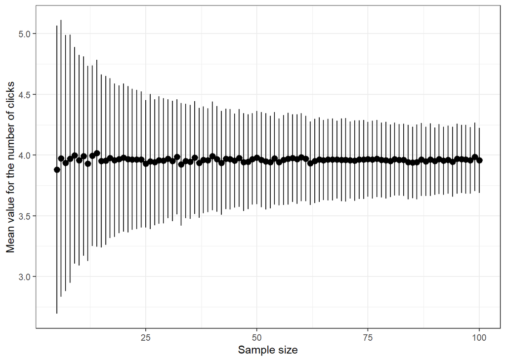

```r
ggplot(cvdata1,aes(x=numb,y=mean))+
  geom_point()+
  theme_bw()+
  geom_pointrange(aes(ymin=mean-sd,  ymax=mean+sd))+ylab("Mean value for the number of clicks")+xlab("Sample size")
```

```r
cvdata$numb=as.numeric(substr(cvdata$id,6,1000))
```

### 4.1.2 2nd sampling from Freya

The average number of sounds per second for clicks present in the clicking period was calculated for Freya2 (second sampling made for Freya data) data (with 100 samples), and the value obtained was 4.92.

```r
nobsF2 <- length(Freya2$clicks)
#Different sample sizes
limitF2 <- 5
nevalF2 <- limitF2:(nobsF2)
#Number of repetitions for each sample size
nrepsF2<-1000
#Object to store the averages
resultadosF2<-matrix(NA,ncol=length(nevalF2),nrow=nrepsF2)
x<-list()
#For each sample size

resultadosF2<-matrix(NA,ncol=length(nevalF2),nrow=nrepsF2)

#For each sample size
for(i in 1:length(nevalF2)){
  #For each repetition
  for(j in 1:nrepsF2){
    amostraF2<-sample(Freya2$clicks,size=nevalF2[i],replace=TRUE)
    resultadosF2[j,i]<-mean(amostraF2)
  }
}


a2<-data.frame(resultadosF2)
colnames(a2)<-paste("size",nevalF2,sep="_")

a2$rep=1:nrow(a2)


cvdata22<-  a2 %>%
  pivot_longer(starts_with("size_") ,
               names_to = "id",
               values_to = "value",
               values_drop_na = TRUE)


cvdata2<-cvdata22%>%
  group_by(id)%>%
  summarise(mean=mean(value),sd=sd(value),cv=sd/mean, numb=as.numeric(substr(id,6,1000)))
```

```
## argument.
```

```r
cvdata2<-cvdata2[!duplicated(cvdata2),]
```

#### 4.1.2.1 Plot for the mean and sd along the increase of the number of samples

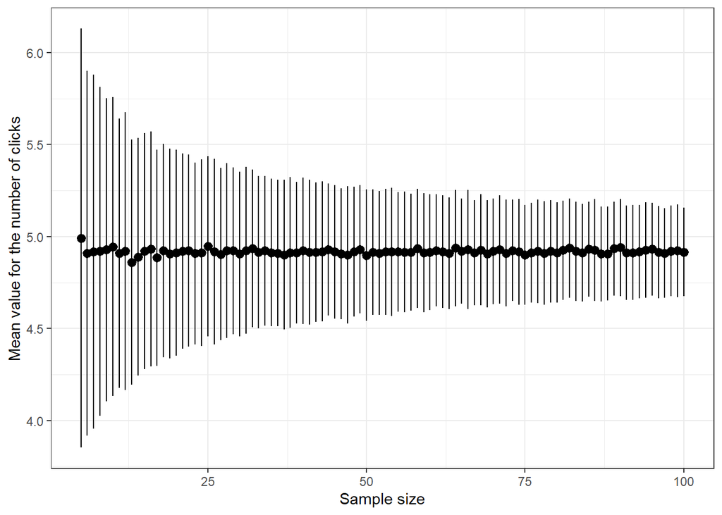

```r
ggplot(cvdata2,aes(x=numb,y=mean))+
  geom_point()+
  theme_bw()+
  geom_pointrange(aes(ymin=mean-sd,  ymax=mean+sd))+ylab("Mean value for the number of clicks")+xlab("Sample size")
```

```r
cvdata22$numb=as.numeric(substr(cvdata22$id,6,1000))
```

### 4.1.3 For the two samples together

The average number of sounds per second for clicks present in the clicking period was calculated for Freya1 and Freya2 data (with a total of 200 samples), and the value obtained was 4.44.

```r
nobsF3 <- length(Freya3$clicks)
#Different sample sizes
limitF3 <- 5
nevalF3 <- limitF3:(nobsF3)
#Number of repetitions for each sample size
nrepsF3<-100
#Object to store the averages
resultadosF3<-matrix(NA,ncol=length(nevalF3),nrow=nrepsF3)
x<-list()
#For each sample size

resultadosF3<-matrix(NA,ncol=length(nevalF3),nrow=nrepsF3)

#For each sample size
for(i in 1:length(nevalF3)){
  #For each repetition
  for(j in 1:nrepsF3){
    amostraF3<-sample(Freya3$clicks,size=nevalF3[i],replace=TRUE)
    resultadosF3[j,i]<-mean(amostraF3)
  }
}


a3<-data.frame(resultadosF3)
colnames(a3)<-paste("size",nevalF3,sep="_")
#a$sd<-apply(resultadosF3,3,sd)
#a$mean<-apply(resultadosF3,3,mean)
#a$cv<-a$sd/a$mean

a3$rep=1:nrow(a3)


cvdata33<-  a3 %>%
  pivot_longer(starts_with("size_") ,
               names_to = "id",
               values_to = "value",
               values_drop_na = TRUE)

cvdata3<-cvdata33%>%
  group_by(id)%>%
  summarise(mean=mean(value),sd=sd(value),cv=sd/mean, numb=as.numeric(substr(id,6,1000)))
```

```
## argument.
```

```r
cvdata3<-cvdata3[!duplicated(cvdata3),]
```

#### 4.1.3.1 Plot for the mean and sd along the increase of the number of samples

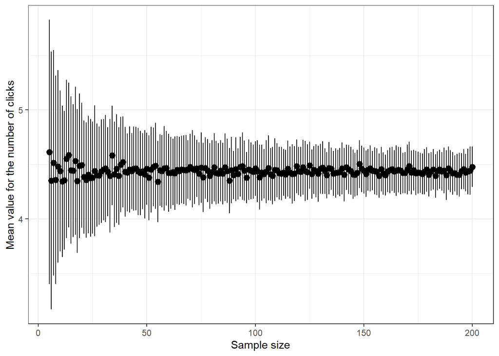

```r
ggplot(cvdata3,aes(x=numb,y=mean))+
  geom_point()+
  theme_bw()+
  geom_pointrange(aes(ymin=mean-sd,  ymax=mean+sd))+ylab("Mean value for the number of clicks")+xlab("Sample size")
```

```r
cvdata33$numb=as.numeric(substr(cvdata33$id,6,1000))
```

### 4.1.4 Seeing if the variance in the average explains the differences between the means obtained for Freya1 and Freya2

```r
Freya1$samp<-"1st sample"
Freya2$samp<-"2nd sample"
Freya3$samp<-"Both samples"
Freya_allsamp1<-rbind(Freya1,Freya2,Freya3)


cvdata1$samp<-"1st sample"
cvdata2$samp<-"2nd sample"
cvdata3$samp<-"Both samples"

cvdata$samp<-"1st sample"
cvdata22$samp<-"2nd sample"
cvdata33$samp<-"Both samples"

Freya_allsamp<-rbind(cvdata,cvdata22,cvdata33)

Freya_allsamp1<-Freya_allsamp1%>%
  group_by(samp)%>%
  mutate(mean=mean(clicks))
```

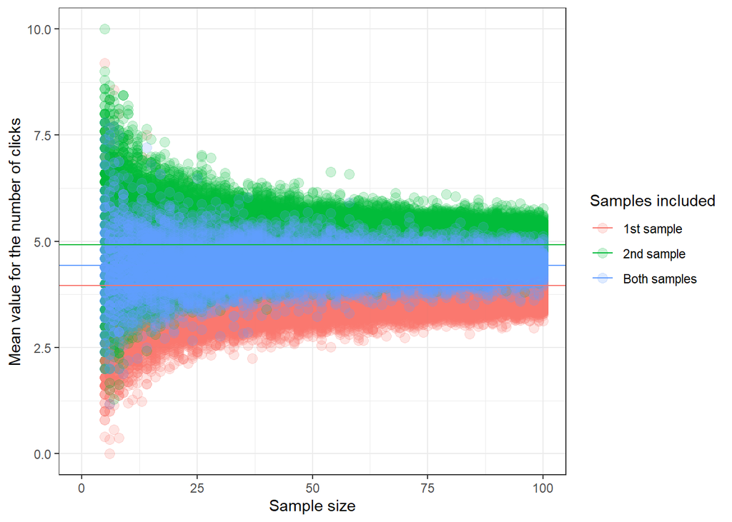

```r
ggplot(Freya_allsamp,aes(x=numb,y=value,color=samp))+
  geom_point(size=3,alpha=0.2,shape=19)+
  theme_bw()+xlim(0,100)+
  geom_hline(data=Freya_allsamp1, aes(yintercept=mean, color=samp,group=samp)) +ylab("Mean value for the number of clicks")+xlab("Sample size")+labs(color="Samples included")
```

It can be concluded that the means obtained for Freya1 and Freya2 data (represented by color lines) are within the interval of the average of each sampling from the other data. Hence, the variance in the average explains the differences between the means obtained for Freya1 and Freya2.

## 4.2 Balder

### 4.2.1 Seeing how increasing the sample size changes the estimates

```r
nobsB <- length(Balder1$clicks)
#Different sample sizes
limitB <- 5
nevalB <- limitB:(nobsB-limitB)
#Number of repetitions for each sample size
nrepsB<-1000
#Object to store the averages
resultadosB<-matrix(NA,ncol=length(nevalB),nrow=nrepsB)

#For each sample size
for(i in 1:length(nevalB)){
  #For each repetition
  for(j in 1:nrepsB){
    amostraB<-sample(Balder1$clicks,size=nevalB[i],replace=TRUE)
    resultadosB[j,i]<-mean(amostraB)
  }
}




b<-data.frame(resultadosB)
colnames(b)<-paste("size",nevalB,sep="_")

b$rep=1:nrow(b)


cvdatab<-  b %>%
  pivot_longer(starts_with("size_") ,
               names_to = "id",
               values_to = "value",
               values_drop_na = TRUE)


cvdatab1<-cvdatab%>%
  group_by(id)%>%
  summarise(mean=mean(value),sd=sd(value),cv=sd/mean, numb=as.numeric(substr(id,6,1000)))
```

```
## argument.
```

```r
cvdatab1<-cvdatab1[!duplicated(cvdatab1),]
```

#### 4.2.1.1 Plot for the mean and sd along the increase of the number of samples

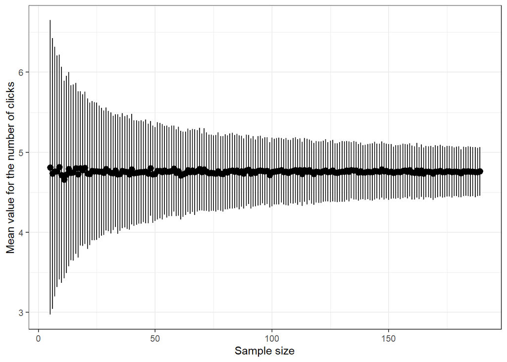

```r
ggplot(cvdatab1,aes(x=numb,y=mean))+
  geom_point()+
  theme_bw()+
  geom_pointrange(aes(ymin=mean-sd,  ymax=mean+sd))+ylab("Mean value for the number of clicks")+xlab("Sample size")
```

## 4.3 Eistla

### 4.3.1 Seeing how increasing the sample size changes the estimates

The next plots show for each sample size, a sub-sample of k samples out of 150 that were selected, between sample sizes of xmin and xmax, and the average was computed.

```r
nobsE <- length(Eistla1$clicks)
#Different sample sizes
limitE <- 5
nevalE <- limitE:(nobsE-limitE)
#Number of repetitions for each sample size
nrepsE<-1000
#Object to store the averages
resultadosE<-matrix(NA,ncol=length(nevalE),nrow=nrepsE)

#For each sample size
for(i in 1:length(nevalE)){
  #For each repetition
  for(j in 1:nrepsE){
    amostraE<-sample(Eistla1$clicks,size=nevalE[i],replace=TRUE)
    resultadosE[j,i]<-mean(amostraE)
  }
}



e<-data.frame(resultadosE)
colnames(e)<-paste("size",nevalE,sep="_")

e$rep=1:nrow(a)


cvdatae<-  e %>%
  pivot_longer(starts_with("size_") ,
               names_to = "id",
               values_to = "value",
               values_drop_na = TRUE)


cvdatae1<-cvdatae%>%
  group_by(id)%>%
  summarise(mean=mean(value),sd=sd(value),cv=sd/mean, numb=as.numeric(substr(id,6,1000)))
```

```
## argument.
```

```r
cvdatae1<-cvdatae1[!duplicated(cvdatae1),]
```

#### 4.3.1.1 Plot for the mean and sd along the increase of the number of samples

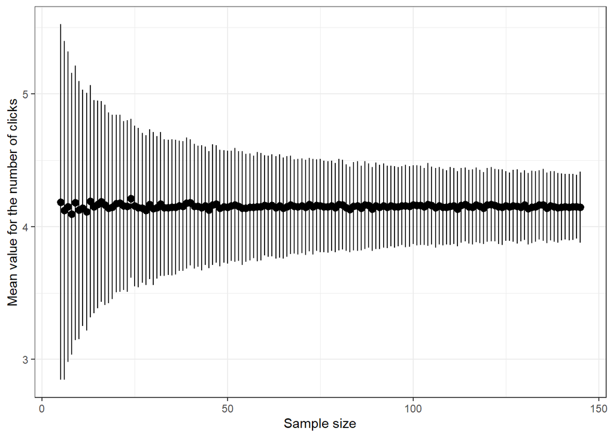

```r
ggplot(cvdatae1,aes(x=numb,y=mean))+
  geom_point()+
  theme_bw()+
  geom_pointrange(aes(ymin=mean-sd,  ymax=mean+sd))+ylab("Mean value for the number of clicks")+xlab("Sample size")
```

## 4.4 Mutti

### 4.4.1 Seeing how increasing the sample size changes the estimates

The average number of sounds per second for clicks present in the clicking period was calculated for Mutti data (with 150 samples), and the value obtained was 4.2.

The next plots show for each sample size, a sub-sample of k samples out of 150 that were selected, between sample sizes of xmin and xmax, and the average was computed.

```r
nobsM <- length(Mutti1$clicks)
#Different sample sizes
limitM <- 5
nevalM <- limitM:(nobsM-limitM)
#Number of repetitions for each sample size
nrepsM<-1000
#Object to store the averages
resultadosM<-matrix(NA,ncol=length(nevalM),nrow=nrepsM)

#For each sample size
for(i in 1:length(nevalM)){
  #For each repetition
  for(j in 1:nrepsM){
    amostraM<-sample(Mutti1$clicks,size=nevalM[i],replace=TRUE)
    resultadosM[j,i]<-mean(amostraM)
  }
}




m<-data.frame(resultadosM)
colnames(m)<-paste("size",nevalM,sep="_")

m$rep=1:nrow(m)


cvdatam<-  m %>%
  pivot_longer(starts_with("size_") ,
               names_to = "id",
               values_to = "value",
               values_drop_na = TRUE)


cvdatam1<-cvdatam%>%
  group_by(id)%>%
  summarise(mean=mean(value),sd=sd(value),cv=sd/mean, numb=as.numeric(substr(id,6,1000)))
```

```
## argument.
```

```r
cvdatam1<-cvdatam1[!duplicated(cvdatam1),]
```

#### 4.4.1.1 Plot for the mean and sd along the increase of the number of samples

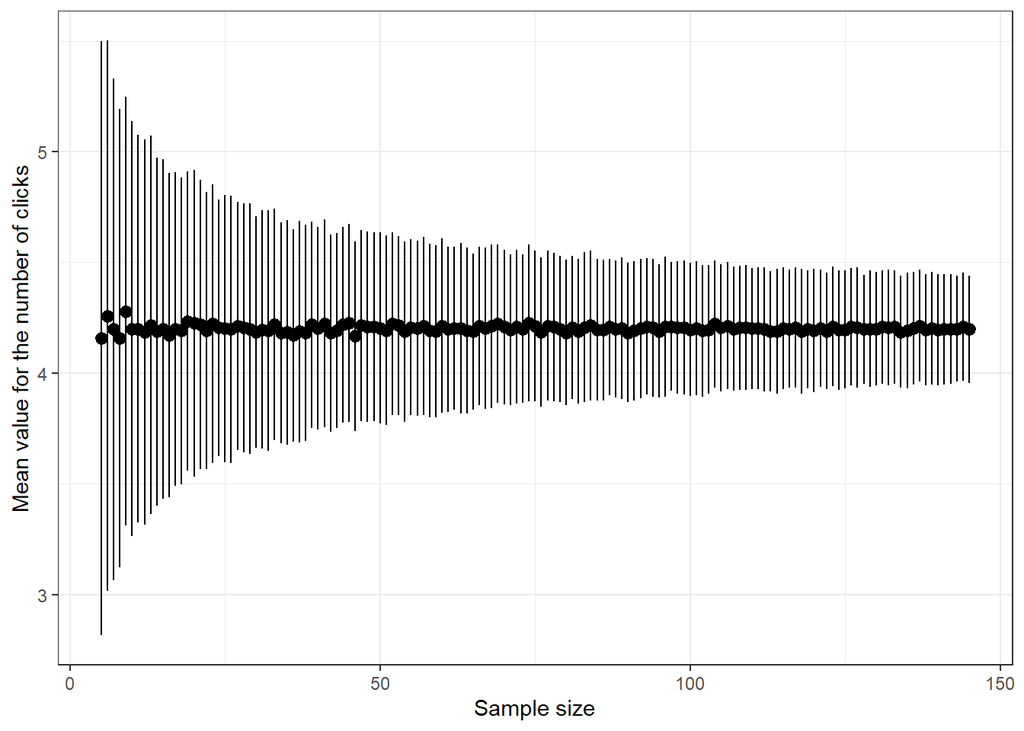

```r
ggplot(cvdatam1,aes(x=numb,y=mean))+
  geom_point()+
  theme_bw()+
  geom_pointrange(aes(ymin=mean-sd,  ymax=mean+sd))+ylab("Mean value for the number of clicks")+xlab("Sample size")
```

## 4.5 Thora

### 4.5.1 Seeing how increasing the sample size changes the estimates

The average number of sounds per second for clicks present in the clicking period was calculated for Thora data (with 150 samples), and the value obtained was 4.3333333.

The next plots show for each sample size, a sub-sample of k samples out of 150 that were selected, between sample sizes of xmin and xmax, and the average was computed.

```r
nobsT <- length(Thora1$clicks)
#Different sample sizes
limitT <- 5
nevalT <- limitT:(nobsT-limitT)
#Number of repetitions for each sample size
nrepsT<-1000
#Object to store the averages
resultadosT<-matrix(NA,ncol=length(nevalT),nrow=nrepsT)

#For each sample size
for(i in 1:length(nevalT)){
  #For each repetition
  for(j in 1:nrepsT){
    amostraT<-sample(Thora1$clicks,size=nevalT[i],replace=TRUE)
    resultadosT[j,i]<-mean(amostraT)
  }
}



t<-data.frame(resultadosT)
colnames(t)<-paste("size",nevalT,sep="_")

t$rep=1:nrow(t)


cvdatat<-  t %>%
  pivot_longer(starts_with("size_") ,
               names_to = "id",
               values_to = "value",
               values_drop_na = TRUE)


cvdatat1<-cvdatat%>%
  group_by(id)%>%
  summarise(mean=mean(value),sd=sd(value),cv=sd/mean, numb=as.numeric(substr(id,6,1000)))
```

```
## argument.
```

```r
cvdatat1<-cvdatat1[!duplicated(cvdatat1),]
```

#### 4.5.1.1 Plot for the mean and sd along the increase of the number of samples

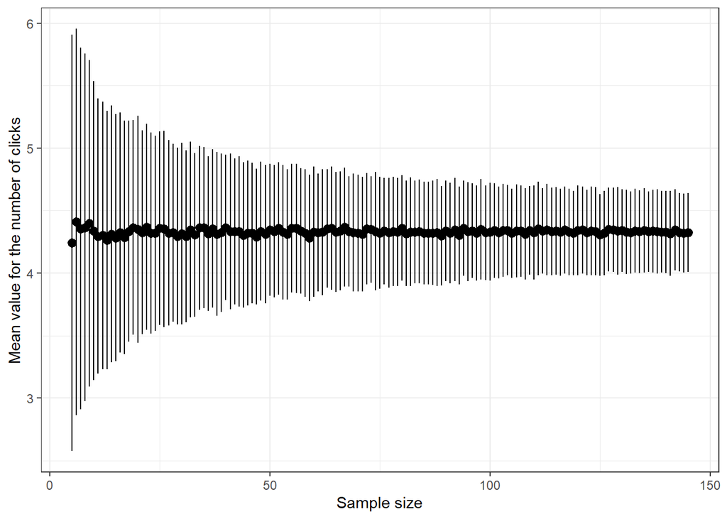

```r
ggplot(cvdatat1,aes(x=numb,y=mean))+
  geom_point()+
  theme_bw()+
  geom_pointrange(aes(ymin=mean-sd,  ymax=mean+sd))+ylab("Mean value for the number of clicks")+xlab("Sample size")
```

## 4.6 Frida

### 4.6.1 Seeing how increasing the sample size changes the estimates

The average number of sounds per second for clicks present in the clicking period was calculated for Frida data (with 149 samples), and the value obtained was 3.8120805.

The next plots show for each sample size, a sub-sample of k samples out of 149 that were selected, between sample sizes of xmin and xmax, and the average was computed.

```r
nobsF <- length(Frida1$clicks)
#Different sample sizes
limitF <- 5
nevalF <- limitF:(nobsF-limitF)
#Number of repetitions for each sample size
nrepsF<-1000
#Object to store the averages
resultadosF<-matrix(NA,ncol=length(nevalF),nrow=nrepsF)

#For each sample size
for(i in 1:length(nevalF)){
  #For each repetition
  for(j in 1:nrepsF){
    amostraF<-sample(Frida1$clicks,size=nevalF[i],replace=TRUE)
    resultadosF[j,i]<-mean(amostraF)
  }
}


f<-data.frame(resultadosF)
colnames(f)<-paste("size",nevalF,sep="_")

f$rep=1:nrow(f)


cvdataf<-  f %>%
  pivot_longer(starts_with("size_") ,
               names_to = "id",
               values_to = "value",
               values_drop_na = TRUE)


cvdataf1<-cvdataf%>%
  group_by(id)%>%
  summarise(mean=mean(value),sd=sd(value),cv=sd/mean, numb=as.numeric(substr(id,6,1000)))
```

```
## argument.
```

```r
cvdataf1<-cvdataf1[!duplicated(cvdataf1),]
```

#### 4.6.1.1 Plot for the mean and sd along the increase of the number of samples

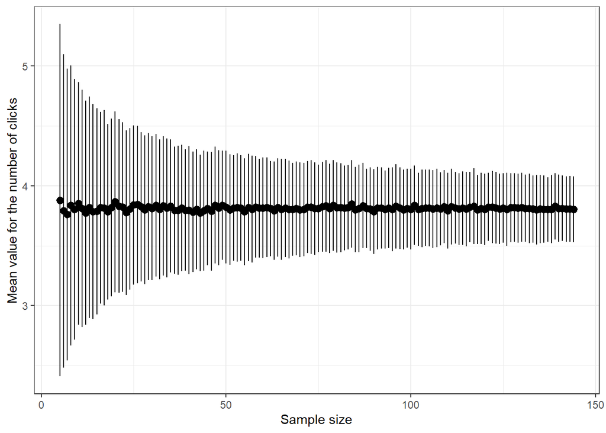

```r
ggplot(cvdataf1,aes(x=numb,y=mean))+
  geom_point()+
  theme_bw()+
  geom_pointrange(aes(ymin=mean-sd,  ymax=mean+sd))+ylab("Mean value for the number of clicks")+xlab("Sample size")
```

## 4.7 Jonas

### 4.7.1 Seeing how increasing the sample size changes the estimates

The average number of sounds per second for clicks present in the clicking period was calculated for Jonas data (with 200 samples), and the value obtained was 4.095.

The next plots show for each sample size, a sub-sample of k samples out of 200 that were selected, between sample sizes of xmin and xmax, and the average was computed.

```r
nobsJ <- length(Jonas1$clicks)
#Different sample sizes
limitJ <- 5
nevalJ <- limitJ:(nobsJ-limitJ)
#Number of repetitions for each sample size
nrepsJ<-1000
#Object to store the averages
resultadosJ<-matrix(NA,ncol=length(nevalJ),nrow=nrepsJ)

#For each sample size
for(i in 1:length(nevalJ)){
  #For each repetition
  for(j in 1:nrepsJ){
    amostraJ<-sample(Jonas1$clicks,size=nevalJ[i],replace=TRUE)
    resultadosJ[j,i]<-mean(amostraJ)
  }
}



j<-data.frame(resultadosJ)
colnames(j)<-paste("size",nevalJ,sep="_")

j$rep=1:nrow(j)


cvdataj<-  j %>%
  pivot_longer(starts_with("size_") ,
               names_to = "id",
               values_to = "value",
               values_drop_na = TRUE)


cvdataj1<-cvdataj%>%
  group_by(id)%>%
  summarise(mean=mean(value),sd=sd(value),cv=sd/mean, numb=as.numeric(substr(id,6,1000)))
```

```
## argument.
```

```r
cvdataj1<-cvdataj1[!duplicated(cvdataj1),]
```

#### 4.7.1.1 Plot for the mean and sd along the increase of the number of samples

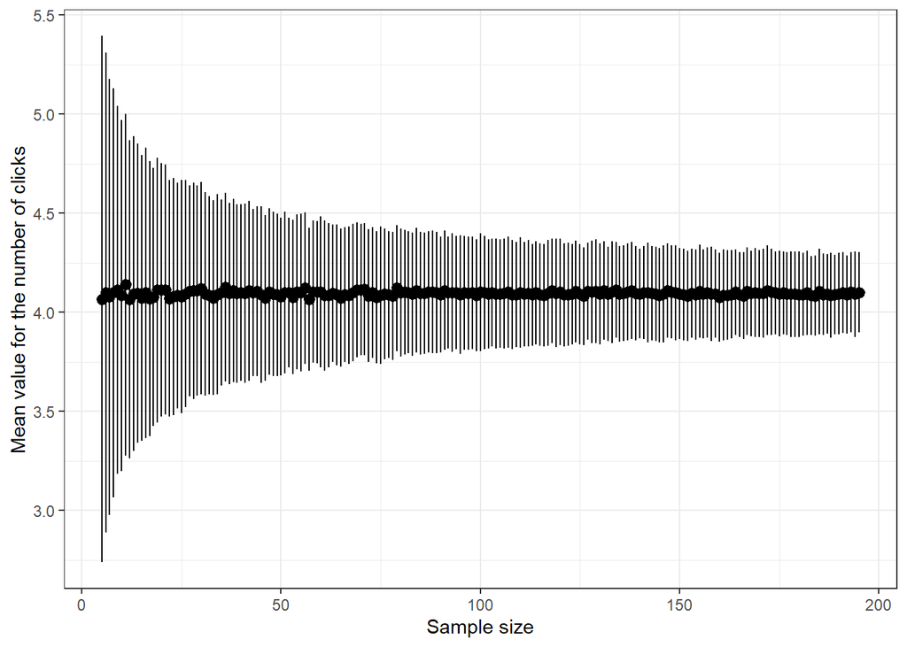

```r
ggplot(cvdataj1,aes(x=numb,y=mean))+
  geom_point()+
  theme_bw()+
  geom_pointrange(aes(ymin=mean-sd,  ymax=mean+sd))+ylab("Mean value for the number of clicks")+xlab("Sample size")
```

## 4.8 Mára

A power reset on Mara record lead to just 1h of clicking and buzzing recorded (Blackwell *et al.* (2018)), so only 10 samples were selected for Mara data. Because of her small sample size, we should use the following results carefully:

### 4.8.1 Seeing how increasing the sample size changes the estimates

The average number of sounds per second for clicks present in the clicking period was calculated for Mara data (with 10 samples), and the value obtained was 5.

The next plots show for each sample size, a sub-sample of k samples out of 10 that were selected, between sample sizes of xmin and xmax, and the average was computed.

```r
nobsMa <- length(Mara1$clicks)
#Different sample sizes
limitMa <- 1
nevalMa <- limitMa:(nobsMa-limitMa)
#Number of repetitions for each sample size
nrepsMa<-1000
#Object to store the averages
resultadosMa<-matrix(NA,ncol=length(nevalMa),nrow=nrepsMa)

#For each sample size
for(i in 1:length(nevalMa)){
  #For each repetition
  for(j in 1:nrepsMa){
    amostraMa<-sample(Mara1$clicks,size=nevalMa[i],replace=TRUE)
    resultadosMa[j,i]<-mean(amostraMa)
  }
}


ma<-data.frame(resultadosMa)
colnames(ma)<-paste("size",nevalMa,sep="_")

ma$rep=1:nrow(ma)


cvdatama<-  ma %>%
  pivot_longer(starts_with("size_") ,
               names_to = "id",
               values_to = "value",
               values_drop_na = TRUE)


cvdatama1<-cvdatama%>%
  group_by(id)%>%
  summarise(mean=mean(value),sd=sd(value),cv=sd/mean, numb=as.numeric(substr(id,6,1000)))
```

```
## argument.
```

```r
cvdatama1<-cvdatama1[!duplicated(cvdatama1),]
```

#### 4.8.1.1 Plot for the mean and sd along the increase of the number of samples

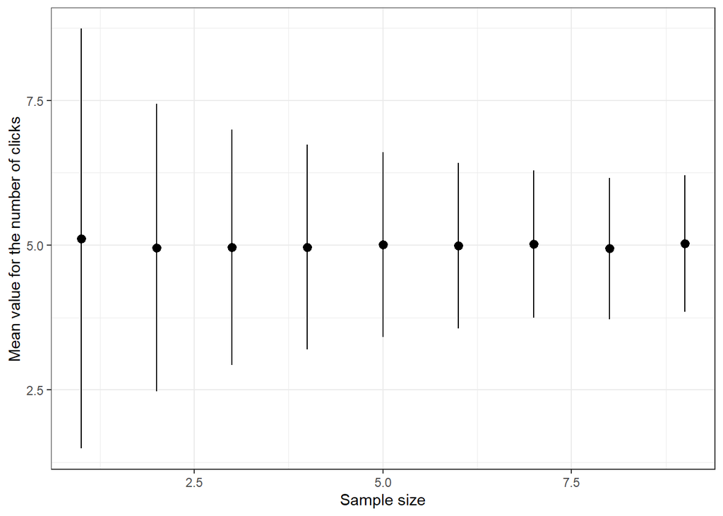

```r
ggplot(cvdatama1,aes(x=numb,y=mean))+
  geom_point()+
  theme_bw()+
  geom_pointrange(aes(ymin=mean-sd,  ymax=mean+sd))+ylab("Mean value for the number of clicks")+xlab("Sample size")
```

## 4.9 Plotting results with all of the narwhals / Figure 3

```r
cvdatama1$whale<-"Mára"
cvdatat1$whale<-"Thora"
cvdatab1$whale<-"Balder"
cvdatae1$whale<-"Eistla"
cvdataf1$whale<-"Frida"
cvdataj1$whale<-"Jonas"
cvdatam1$whale<-"Mutti"
cvdata3$whale<-"Freya"

ddata<-full_join(cvdatama1,cvdatat1)
ddata<-full_join(ddata,cvdatab1)
ddata<-full_join(ddata,cvdatae1)
ddata<-full_join(ddata,cvdataf1)
ddata<-full_join(ddata,cvdataj1)
ddata<-full_join(ddata,cvdatam1)
ddata<-full_join(ddata,cvdata3)
ddata$whale<-factor(ddata$whale,levels=c("Freya","Thora","Mára","Frida","Eistla","Balder","Jonas","Mutti"))
```

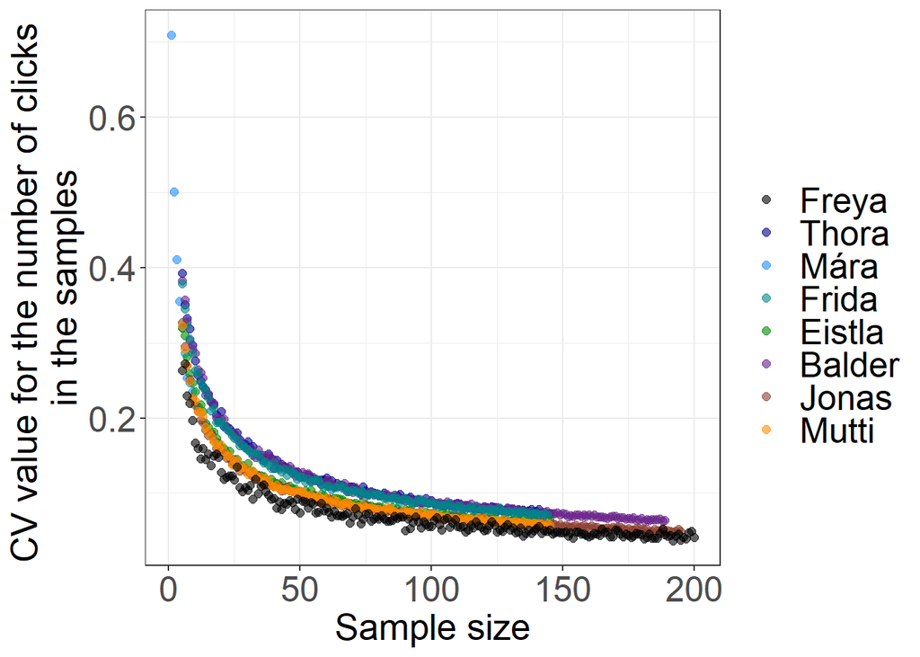

```r
ggplot(data=ddata,aes(x=numb,y=cv,color=whale))+
  geom_point(alpha=0.6,size=2)+
  theme_bw()+ylab("CV value for the number of clicks \nin the samples")+xlab("Sample size")+  scale_color_manual(values=c("black", "blue4","dodgerblue1","turquoise4","green4","darkorchid4","coral4","darkorange"))+labs(fill="",color="")+
  theme(
        axis.title.x = element_text(size = 20),
        axis.text.x = element_text(size = 19),
        axis.text.y = element_text(size = 19),
        axis.title.y = element_text(size = 20),
        legend.title = element_text(size=20),
        legend.text= element_text(size=19),
        plot.title = element_text(size=20),
        strip.text.x = element_text(size = 21))
```

```r
ggsave("Figures/Figure3.jpeg",dpi=600)
```

Seeing how increasing the sample size changes the estimates for Freya1. 100 samples seem to be enough to have a good estimate of narwhal cue rates and density since the coefficient of variation of the average number of clicks is less than 20% (Gomez & Gomez (1984)).

# References

Blackwell, S.B., Tervo, O.M., Conrad, A.S., Sinding, M.H.S., Hansen, R.G., Ditlevsen, S. & Heide-Jørgensen, M.P. (2018). Spatial and temporal patterns of sound production in east greenland narwhals. *PLOS ONE*, **13**, e0198295. Retrieved from https://doi.org/10.1371/journal.pone.0198295

Gomez, K.A. & Gomez, A.A. (1984). *Statistical procedures for agricultural research*. John Wiley; Sons, Inc, New York.